# Model AMA

Olga Sieradzan

2025-03-05

```r
library(foreign)
library(dplyr)
library(cowplot)
library(ggplot2)
library(readr)
library(readxl)
library(MASS)
library(fitdistrplus)
library(psych)
library(gridExtra)
database <- read.csv("C:/Users/olgas/OneDrive/Documents/GitHub/Quantative-risk-models-summit/Model AMA/plik1.csv")
```

# Wstęp

W poniżym projekcie, postanowiono wynzczyć Operacyjne indeksy ryzyka z wykorzytsnaiem modelu AMA. W tym celu przeprowadzono podobane kroki: Dopasowanie rozkładów oraz przeprowadzenie symulacji.

# Dopasowanie rozkładów

Kluczowym krokiem w badaniu jest dopasowanie odpowiednich rozkładów do wszytskich 7 linii biznesowych omawianych w badaniu. Rozkłady będą dopasowywane do częstości występowania strat oraz wysokości wartości strat. Częstość występowania start jest rozkładem dyskretnym dlatego w badaniu rozważane będzie dopasowanie do rozkładu dwumianowego, dwumianowego ujemnego, geometrycznego oraz rozkładu poissona. Wysokośc wartości strat jest rozkładem ciagłym, staąd sprawdzane będzie dopasowanie do rozkładu normlangeo, logarytmicznego-normalnego, wykładniczego, gamma oraz weibulla.

## Rozkład częstości strat

W tej części zostanie dopasowane siedem rozkładów do niżej zaprezentowanych danych

**Ilośći start na rok**

```r
n <- data.frame(table(database$linia))

bus <- data.frame(table(database$rok[database$linia == "Buss_Distr"]))
com <- data.frame(table(database$rok[database$linia == "Com_Ban"]))
dam <- data.frame(table(database$rok[database$linia == "Damage"]))
empl <- data.frame(table(database$rok[database$linia == "Empl_Pract"]))
del <- data.frame(table(database$rok[database$linia == "Execut_Del"]))
ex <- data.frame(table(database$rok[database$linia == "External_Fr"]))
intr <- data.frame(table(database$rok[database$linia == "Internal_Fr"]))
colnames(bus) <- c("Year", "Buss_Distr")
colnames(com) <- c("Year", "Com_Ban")
colnames(dam) <- c("Year", "Damage")
colnames(empl) <- c("Year", "Empl_Pract")
colnames(del) <- c("Year", "Execut_Del")
colnames(ex) <- c("Year", "External_Fr")
colnames(intr) <- c("Year", "Internal_Fr")

df_list <- list(bus, com, dam, empl, del, ex, intr)

final_df <- Reduce(function(x, y) merge(x, y, by = "Year", all = TRUE), df_list)

final_df
```

| Year | Buss_Distr | Com_Ban | Damage | Empl_Pract | Execut_Del | External_Fr | Internal_Fr |
| --- | --- | --- | --- | --- | --- | --- | --- |
| 1989 | 9 | 17 | 15 | 59 | 15 | 9 | 111 |
| 1990 | 5 | 16 | 17 | 69 | 16 | 9 | 78 |
| 1991 | 9 | 14 | 11 | 60 | 12 | 6 | 103 |
| 1992 | 9 | 17 | 14 | 68 | 14 | 5 | 98 |
| 1993 | 7 | 14 | 30 | 50 | 16 | 7 | 86 |
| 1994 | 7 | 8 | 11 | 61 | 13 | 9 | 90 |
| 1995 | 4 | 16 | 23 | 58 | 16 | 8 | 129 |
| 1996 | 5 | 16 | 19 | 68 | 12 | 6 | 106 |
| 1997 | 5 | 12 | 8 | 57 | 8 | 9 | 107 |
| 1998 | 7 | 15 | 4 | 57 | 14 | 5 | 96 |

[output cut: 25 more lines]

Na sam początek w dopasowaniu może pomóc obliczenie statystyk opisowych dla każdego rozkładu. Sczegołnie interesującymi jest wariancja oraz średnia. Różnica między tymi dwoma statystykami jest ważną informacją przy wyborze rozkładu.

```r
numeric_df <- final_df[, -1]

means <- colMeans(numeric_df, na.rm = TRUE)

variances <- apply(numeric_df, 2, var, na.rm = TRUE)

stats_df <- data.frame(
  Średnia = means,
  Wariancja = variances,
  Różnica = means - variances

)

stats_df
```

|  | Średnia | Wariancja | Różnica |
| --- | --- | --- | --- |
| Buss_Distr | 6.600000 | 3.247059 | 3.352941 |
| Com_Ban | 14.257143 | 8.196639 | 6.060504 |
| Damage | 16.200000 | 46.988235 | -30.788235 |
| Empl_Pract | 62.114286 | 38.633613 | 23.480672 |
| Execut_Del | 14.342857 | 7.761345 | 6.581513 |
| External_Fr | 6.914286 | 2.904202 | 4.010084 |
| Internal_Fr | 99.628571 | 209.181513 | -109.552941 |

Wszytskie różnice wydają się istotne, stąd prawdopodobnie rozkład Poissona może nie być najlepszym dopasowaniem. W większości przypadków różnica wskazuje na rozkład dwumianowy ($E(X) > D^2(X)$), jednak w dwóch przypadkach mozliwy jest rozkład dwumianowy ujemny, ze względy na przeciwną zależnośc średniej i wariancji.

Potencjalne wartości parametrów wszytskich rozwazanych rozkładów, łatwo obliczyć ze wzorów lub za pomocą funkcji dopasowywujących. Do weryfikacji testów przeproadzono test statystyczny chi-kwadrat z poziomem istotności$\alpha = 0.05$

**Rozkład ujemny dwumianowy**

W przypadku dwóch lini, róznica wyszła znacząco ujemna. Wskazuje to mozliwość że badane rozkłady to rozkłady ujemne dwumianowe

```r
r_neg_binom <- (stats_df$Średnia)^2 / (stats_df$Wariancja - stats_df$Średnia)
p_neg_binom <- stats_df$Średnia / stats_df$Wariancja

dwu_uj <- data.frame(
  Line = names(means),
  r = r_neg_binom,
  p = p_neg_binom
)

dwu_uj <- dwu_uj[c(3,7),]

fit_negbin_with_tests <- function(data) {
  fit <- fitdist(data, "nbinom",
                method = "mse",
                start = list(size = 1, mu = mean(data)))
  gof <- gofstat(fit)
  chisq_test <- ifelse(gof$chisqpvalue < 0.05, "H0 odrzucona", "H0 nieodrzucona")


  return(list(
    size = round( fit$estimate["size"], 0),
    mu = fit$estimate["mu"],
    chisq_result = chisq_test
  ))
}




results <- mapply(fit_negbin_with_tests,
                 final_df[,c(4,8)],
                 SIMPLIFY = FALSE)

dwu_uj$size <- sapply(results, function(x) x$size)
dwu_uj$mu <- sapply(results, function(x) x$mu)
dwu_uj$chisq_test <- sapply(results, function(x) x$chisq_result)


dwu_uj[,c(1,4,5,6)]
```

|  | Line | size | mu | chisq_test |
| --- | --- | --- | --- | --- |
| 3 | Damage | 4 | 18.56427 | H0 nieodrzucona |
| 7 | Internal_Fr | 60 | 100.83760 | H0 nieodrzucona |

Podejżenia okazały sie prawidłowe, w przeprowadzonych testach chii-kwadrat, hipoteza głowna została nieodrzucoana, w obydwóch przypadakch.

**Rozkład dwumianowy**

```r
N = (stats_df$Średnia)^2/ (stats_df$Różnica)

dwu_df <- data.frame(
  Line = names(means),
  n = round(N, 0),
  p = (stats_df$Średnia)/ N
)

dwu_df1 <- dwu_df[c(1,2,4,5,6),]



fit_binomial_with_tests <- function(data, n) {

  fit <- fitdist(data, "binom",
                start = list(prob = 0.5),
                fix.arg = list(size = n),
                method = "mse")

  gof <- gofstat(fit)


  chisq_test <- ifelse(gof$chisqpvalue < 0.05, "H0 odrzucona", "H0 nieodrzucona")


  return(list(
    p = fit$estimate["prob"],
    size = fit$estimate["size"],
    chisq_result = chisq_test
  ))
}


results <- mapply(fit_binomial_with_tests,
                 final_df[,c(2,3,5,6,7)],
                 360,
                 SIMPLIFY = FALSE)


dwu_df1$p <- sapply(results, function(x) x$p)
dwu_df1$chisq_test <- sapply(results, function(x) x$chisq_result)

dwu_df1
```

|  | Line | n | p | chisq_test |
| --- | --- | --- | --- | --- |
| 1 | Buss_Distr | 13 | 0.02004632 | H0 nieodrzucona |
| 2 | Com_Ban | 34 | 0.04158443 | H0 nieodrzucona |
| 4 | Empl_Pract | 164 | 0.17252835 | H0 odrzucona |
| 5 | Execut_Del | 31 | 0.04066709 | H0 nieodrzucona |
| 6 | External_Fr | 12 | 0.02102162 | H0 nieodrzucona |

Tylko w jednym przypadku test chi-kwadrat nie podtwierdził rozkładu dwumianowego dla częstości występowania start. Rozkład ten zostanie dodatkowo prztestowany dla dopasowania do rozkładu geometrycznego i rozkładu poissona.

**Rozkład Poissona**

```r
fit_poisson_simple <- function(data) {

  fit <- fitdist(data, "pois", start = list(lambda = mean(data)))
  gof <- gofstat(fit)

  return(list(
    lambda = fit$estimate,
    chisq_test = ifelse(gof$chisqpvalue < 0.05,
                       "H0 odrzucona",
                       "H0 nieodrzucona")
  ))
}


results <- fit_poisson_simple(
                 as.vector(final_df$Empl_Pract)
                 )

dw_po <- data.frame(
  Line = "Empl_Prac",
  lambda = results$lambda,
  chisq_test = results$chisq_test
)

dw_po
```

|  | Line | lambda | chisq_test |
| --- | --- | --- | --- |
| lambda | Empl_Prac | 62.11429 | H0 odrzucona |

**Rozkład geometryczny**

```r
fit_geometric_simple <- function(data) {


  fit <- fitdist(data, "geom", method = "mle")


  gof <- gofstat(fit)

  return(list(
    prob = fit$estimate["prob"],  # Parametr rozkładu geometrycznego
    chisq_test = ifelse(gof$chisqpvalue < 0.05,
                       "H0 odrzucona",
                       "H0 nieodrzucona")
  ))
}

results <- fit_geometric_simple(
  as.vector(final_df$Empl_Pract)
)

dw_geom <- data.frame(
  Line = "Empl_Prac",
  prob = results$prob,
  chisq_test = results$chisq_test
)


dw_geom
```

|  | Line | prob | chisq_test |
| --- | --- | --- | --- |
| prob | Empl_Prac | 0.01584427 | H0 odrzucona |

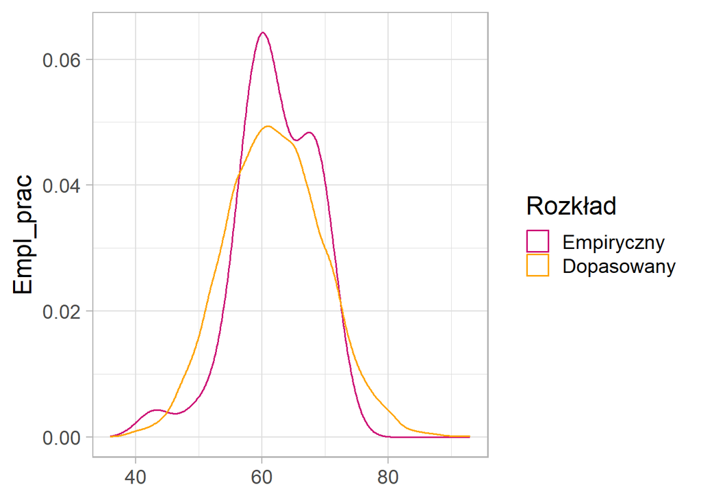

```r
ggplot()+
  geom_density(aes(x = final_df$Empl_Pract, color = "Empiryczny"), size = 0.7) +
  geom_density(aes(x = rpois(10000, lambda = 62), color = "Dopasowany"), size = 0.7)+
    scale_color_manual(values = c("#CD1076", "orange"), breaks = c("Empiryczny", "Dopasowany"))+
  labs (y = "Empl_prac", x = NULL, colour = "Rozkład")+
  theme_light(base_size = 18)
```

Linia Empl_prac niestety nie daje się dopasowac do niczego, poprzez wykorzytsnaie testów statystycznych, dlatego postanowiono że jest rozkładem poissona o lambdzie = 62, ze względuy na najlepsze dopasowanie funkcji gęstości pokazane powyżej.

**Podsumowanie** W poniższej tabeli oraz na wykresach zaprezenowano podsumowanie wykonanych dopasować.

```r
pod <- data.frame(
  Linia = names(means),
  Rozkład = c("Rozkład dwumianowy", "Rozkład dwumianowy", "Rozkład dwumianowy ujemny", "Rozkład Poissona",  "Rozkład dwumianowy","Rozkład dwumianowy", "Rozkład dwumianowy ujemny"),
  Parematry = c("size = 13, p = 0.02", "size = 34, p = 0.04", "size = 4, mu = 18.56", "size = 164, p = 0.17", "size =  31, p = 0.04", "size = 12, p = 0.02", "size = 60, mu = 100.83")
)

pod
```

[output not shown]

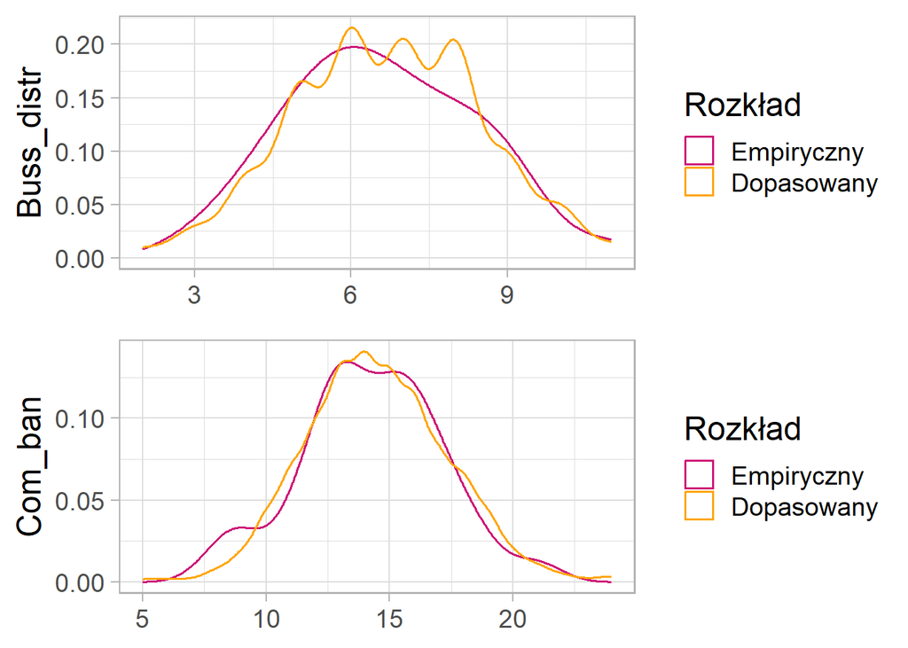

```r
p1 <- ggplot()+
  geom_density( data = final_df, aes(x = Buss_Distr, color = "Empiryczny" ), size = 0.7) +
  geom_density(aes ( x = rbinom(1000, size = dwu_df1$n[1], prob = dwu_df$p[1]), color = "Dopasowany" ), size = 0.7) +
  scale_color_manual(values = c("#CD1076", "orange"), breaks = c("Empiryczny", "Dopasowany"))+
  labs (y = "Buss_distr", x = NULL, colour = "Rozkład")+
  theme_light(base_size = 18)
p2 <- ggplot()+
  geom_density( data = final_df, aes(x = Com_Ban, color = "Empiryczny" ), size = 0.7) +
  geom_density(aes ( x = rbinom(1000, size = dwu_df1$n[2], prob = dwu_df$p[2]), color = "Dopasowany" ), size = 0.7) +
  scale_color_manual(values = c("#CD1076", "orange"), breaks = c("Empiryczny", "Dopasowany"))+
  labs (y = "Com_ban", x = NULL, colour = "Rozkład")+
  theme_light(base_size = 18)

plot_grid(p1, p2, nrow = 2, ncol = 1)
```

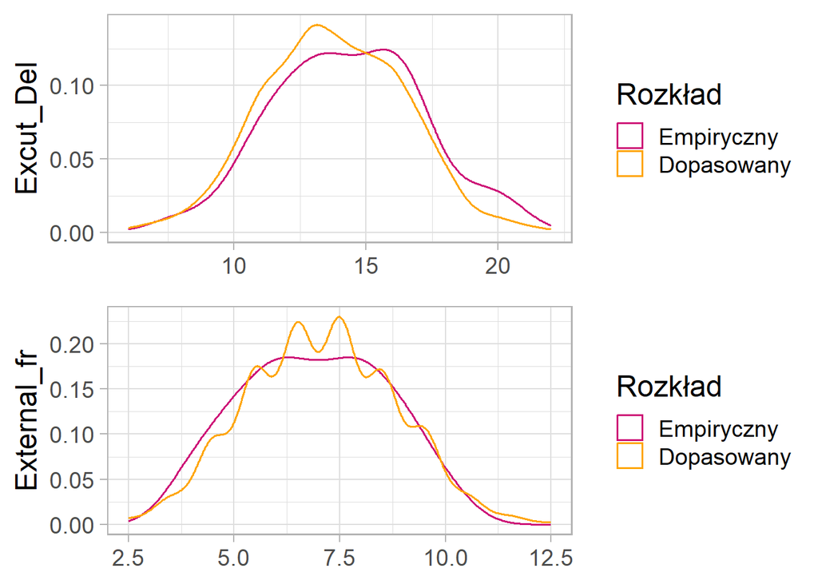

```r
p1 <- ggplot()+
  geom_density( data = final_df, aes(x =Execut_Del, color = "Empiryczny" ), size = 0.7) +
  geom_density(aes ( x = rbinom(1000, size = dwu_df1$n[4], prob = dwu_df$p[4])+2, color = "Dopasowany" ), size = 0.7) +
  scale_color_manual(values = c("#CD1076", "orange"), breaks = c("Empiryczny", "Dopasowany"))+
  labs (y = "Excut_Del", x = NULL, colour = "Rozkład")+
  theme_light(base_size = 18)
p2 <- ggplot()+
  geom_density( data = final_df, aes(x = External_Fr, color = "Empiryczny" ), size = 0.7) +
  geom_density(aes ( x = rbinom(1000, size = dwu_df1$n[5], prob = dwu_df$p[5]) +1.5, color = "Dopasowany" ), size = 0.7) +
  scale_color_manual(values = c("#CD1076", "orange"), breaks = c("Empiryczny", "Dopasowany"))+
  labs (y = "External_fr", x = NULL, colour = "Rozkład")+
  theme_light(base_size = 18)

plot_grid(p1, p2, nrow = 2, ncol = 1)
```

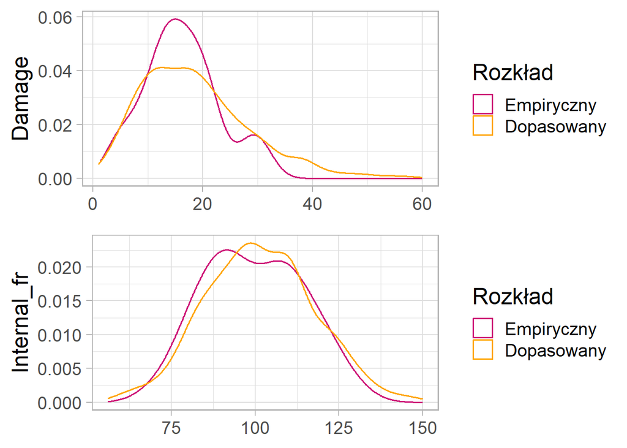

```r
p1 <- ggplot()+
  geom_density( data = final_df, aes(x = Damage, color = "Empiryczny" ), size = 0.7) +
  geom_density(aes ( x = rnbinom(1000, size = dwu_uj$size[1], mu = dwu_uj$mu[1]), color = "Dopasowany" ), size = 0.7) +
  scale_color_manual(values = c("#CD1076", "orange"), breaks = c("Empiryczny", "Dopasowany"))+
  labs (y = "Damage", x = NULL, colour = "Rozkład")+
  theme_light(base_size = 18)
p2 <- ggplot()+
  geom_density( data = final_df, aes(x = Internal_Fr, color = "Empiryczny" ), size = 0.7) +
  geom_density(aes ( x = rnbinom(1000, size = dwu_uj$size[2], mu = dwu_uj$mu[2]), color = "Dopasowany" ), size = 0.7) +
  scale_color_manual(values = c("#CD1076", "orange"), breaks = c("Empiryczny", "Dopasowany"))+
  labs (y = "Internal_fr", x = NULL, colour = "Rozkład")+
  theme_light(base_size = 18)

plot_grid(p1, p2, nrow = 2, ncol = 1)
```

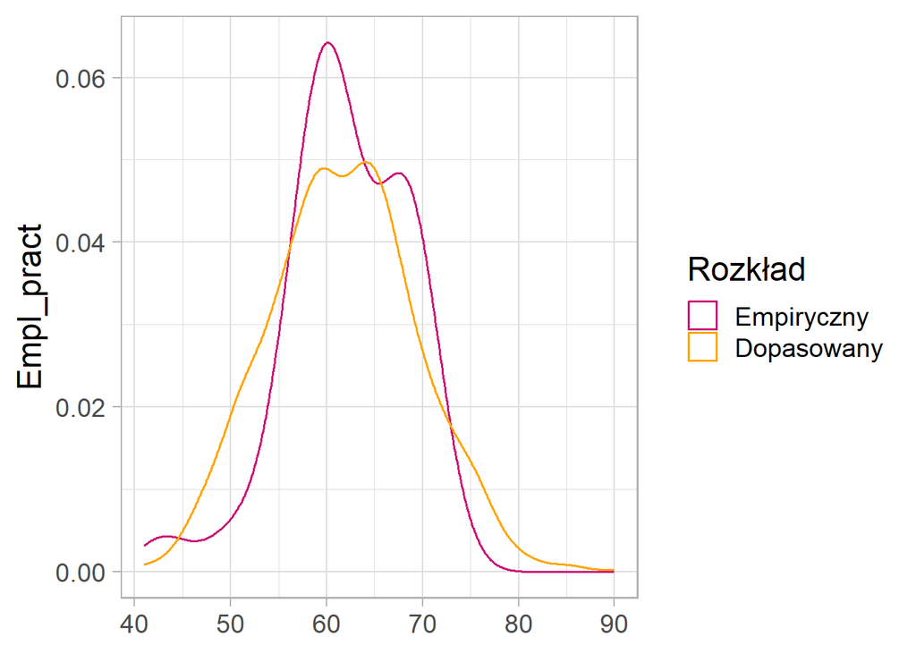

```r
ggplot()+
  geom_density( data = final_df, aes(x = Empl_Pract, color = "Empiryczny" ), size = 0.7) +
  geom_density(aes ( x = rpois(1000, lambda = dw_po$lambda), color = "Dopasowany" ), size = 0.7) +
  scale_color_manual(values = c("#CD1076", "orange"), breaks = c("Empiryczny", "Dopasowany"))+
  labs (y = "Empl_pract", x = NULL, colour = "Rozkład")+
  theme_light(base_size = 18)
```

Uznano że dopasowanie wyszło dosyć dobrze. Wykresy gęstości rozkładów empirycznych zostały akceptowalnie odwzorowoane przez dopasowane rozkłady gęstości.

## Rozkład wartości strat

Koljenym krokiem w badaniu jest dopasowanie rozkładów do rozkładów start w każdej lini. Ponizej zaprezentowano statystyki opisowe dla 7 badanych linii.

```r
straty_lista <-split(database$strata, database$linia)

straty_stat <- database %>%
  group_by(linia) %>%
  summarise(

    Średnia = mean(strata, na.rm = TRUE),
    Sd = sd(strata, na.rm = TRUE),
    Mediana = median(strata, na.rm = TRUE),
    Liczba_obserwacji = n()
  ) %>%
  arrange(desc(Średnia))

straty_stat
```

| linia | Średnia | Sd | Mediana | Liczba_obserwacji |
| --- | --- | --- | --- | --- |
| Empl_Pract | 40000.000 | 7781.271 | 40080.310 | 2174 |
| Buss_Distr | 36008.765 | 464697.451 | 10.000 | 231 |
| Com_Ban | 33009.524 | 732478.274 | 10.000 | 499 |
| Execut_Del | 5009.013 | 80100.239 | 10.000 | 502 |
| Internal_Fr | 5000.006 | 5023.562 | 3487.910 | 3487 |
| External_Fr | 5000.000 | 5044.628 | 3275.795 | 242 |
| Damage | 4000.000 | 3897.465 | 2805.410 | 567 |

W wielu przypadkach średnia i Mediana drastycznie się od siebie różnią, oraz odchylenie standardowe jest bardzo wysokie, co wskazuje na rozkłady o wysokiej skośności i wariancji wśród danych. Linie też znacząco różnią się od siebie w ilości danych, jednak wszystkich jest na tyle duzo żeby wyniki przeprowadzanych testów i analiz były wiarygodne.

**Wyniki testów**

```r
fit_dis<- function(data_list, distributions = c("weibull", "gamma", "lnorm", "exp", "norm")) {
  results <- data.frame()

  for (linia in names(data_list)) {
    data <- data_list[[linia]]
    data <- data[data > 0]

    for (dist in distributions) {
      fit <- tryCatch({
        fitdist(data, distr = dist, method = "mle")
      }, error = function(e) {
        message(sprintf("Błąd dopasowania %s dla linii %s: %s", dist, linia, e$message))
        return(NULL)
      })

      if (!is.null(fit)) {

        gof <- gofstat(fit)


        results <- rbind(results, data.frame(
          linia = linia,
          rozklad = dist,
          parametry = paste(names(fit$estimate), round(fit$estimate, 4), sep = "=", collapse = ", "),


          KS_wynik = gof$kstest,


          AD_wynik = gof$adtest ,

          AIC = gof$aic,
          stringsAsFactors = FALSE
        ))
      }
    }
  }

  return(results)
}

wyniki <- fit_dis(straty_lista)

rownames(wyniki) <- NULL

wyniki[,c(1:5)]
```

| linia | rozklad | parametry | KS_wynik | AD_wynik |
| --- | --- | --- | --- | --- |
| Buss_Distr | weibull | shape=0.2849, scale=50.2673 | rejected | rejected |
| Buss_Distr | gamma | shape=0.1045, rate=0 | rejected | NA |
| Buss_Distr | lnorm | meanlog=2.7611, sdlog=1.7275 | rejected | not computed |
| Buss_Distr | exp | rate=0 | rejected | rejected |
| Buss_Distr | norm | mean=36008.7655, sd=463690.5213 | rejected | not computed |
| Com_Ban | weibull | shape=0.3372, scale=20.3404 | rejected | rejected |
| Com_Ban | gamma | shape=0.1015, rate=0 | rejected | NA |
| Com_Ban | lnorm | meanlog=2.418, sdlog=0.9201 | rejected | not computed |
| Com_Ban | exp | rate=0 | rejected | rejected |
| Com_Ban | norm | mean=33009.5235, sd=731743.9597 | rejected | not computed |

[output cut: 25 more lines]

```r
#ggcomb
```

Same testy okazały sie nie wystarczajace w decyzji na temat konkretnego rozkładu, dodatkowo postanowiono obliczyć kryterium informacyjne AIC, które pomaga w wyborze miedzy modelami statystycznymi. Im niższy jest ten wskażnik, tym lepsze dopasowanie rozkładów.

```r
wyniki[,c(1,2,6)]
```

| linia | rozklad | AIC |
| --- | --- | --- |
| Buss_Distr | weibull | 2473.285 |
| Buss_Distr | gamma | 2829.695 |
| Buss_Distr | lnorm | 2187.733 |
| Buss_Distr | exp | 5311.081 |
| Buss_Distr | norm | 6687.251 |
| Com_Ban | weibull | 4760.295 |
| Com_Ban | gamma | 5791.898 |
| Com_Ban | lnorm | 3750.170 |
| Com_Ban | exp | 11383.742 |
| Com_Ban | norm | 14896.280 |

[output cut: 25 more lines]

Bazując na wynikach testów oraz kryterium AIC, udało się dopasować trzy rozkłady. Wyniki dopasowania zaprezentowano w ponizszej tabeli oraz na wykresach. Dopasowywano rozkłady o dwóch nieodrzuconych testach oraz najniżej wartości AIC

```r
wyniki[c(14,29,34), c(1,2,3)]
```

|  | linia | rozklad | parametry |
| --- | --- | --- | --- |
| 14 | Damage | exp | rate=2e-04 |
| 29 | External_Fr | exp | rate=2e-04 |
| 34 | Internal_Fr | exp | rate=2e-04 |

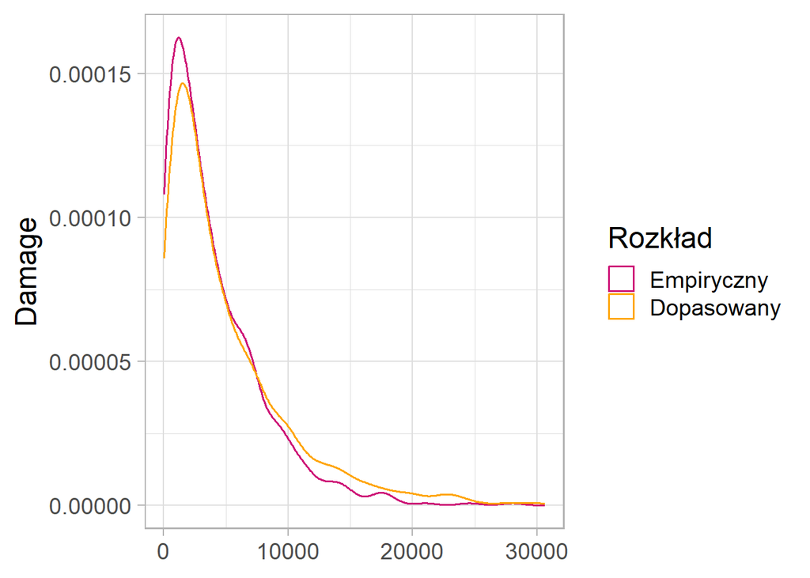

```r
frame_Damage <- data.frame(straty_lista[[3]])

ggplot()+
  geom_density( data = frame_Damage, aes(x = straty_lista..3.., color = "Empiryczny" ), size = 0.7) +
  geom_density(aes ( x = rexp(1000, rate = 0.0002), color = "Dopasowany" ), size = 0.7) +
  scale_color_manual(values = c("#CD1076", "orange"), breaks = c("Empiryczny", "Dopasowany"))+
  labs (y = "Damage", x = NULL, colour = "Rozkład")+
  theme_light(base_size = 18)
```

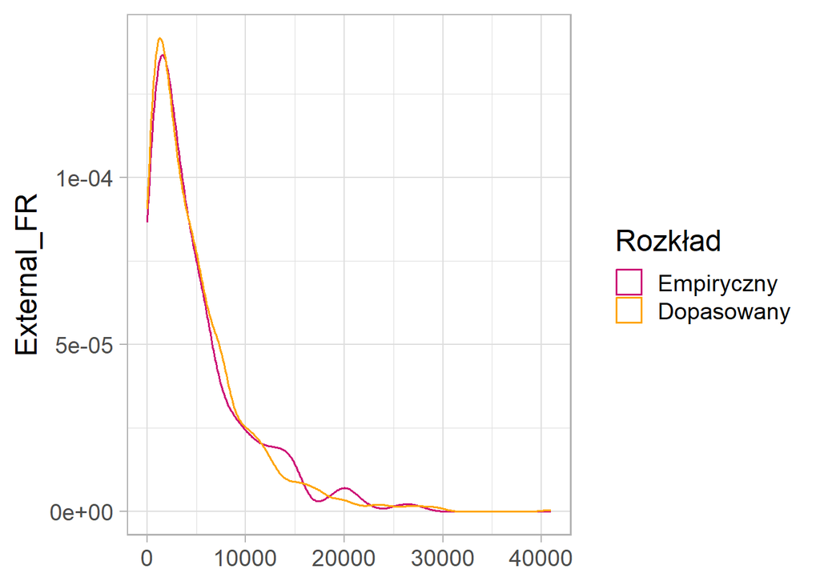

```r
frame_EX<- data.frame(straty_lista[[6]])

ggplot()+
  geom_density( data = frame_EX, aes(x = straty_lista..6.., color = "Empiryczny" ), size = 0.7) +
  geom_density(aes ( x = rexp(1000, rate = 0.0002), color = "Dopasowany" ), size = 0.7) +
  scale_color_manual(values = c("#CD1076", "orange"), breaks = c("Empiryczny", "Dopasowany"))+
  labs (y = "External_FR", x = NULL, colour = "Rozkład")+
  theme_light(base_size = 18)
```

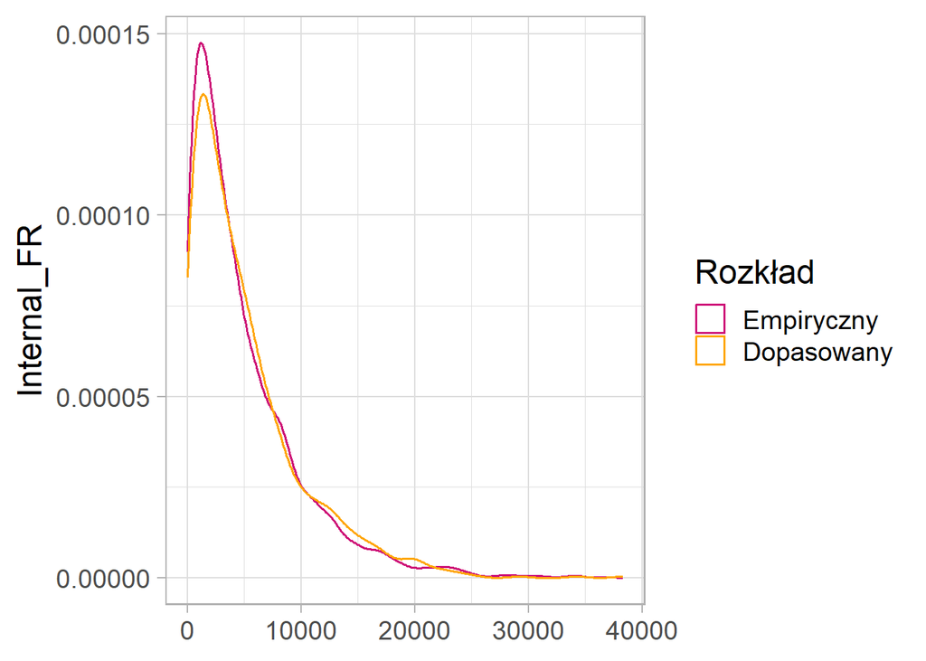

```r
frame_IN<- data.frame(straty_lista[[7]])

ggplot()+
  geom_density( data = frame_IN, aes(x = straty_lista..7.., color = "Empiryczny" ), size = 0.7) +
  geom_density(aes ( x = rexp(1000, rate = 0.0002), color = "Dopasowany" ), size = 0.7) +
  scale_color_manual(values = c("#CD1076", "orange"), breaks = c("Empiryczny", "Dopasowany"))+
  labs (y = "Internal_FR", x = NULL, colour = "Rozkład")+
  theme_light(base_size = 18)
```

Poniżej zaprzenowano rozkłady gęstości czterech wykresów gdzie dopasowanie nie jest jednoznaczne.

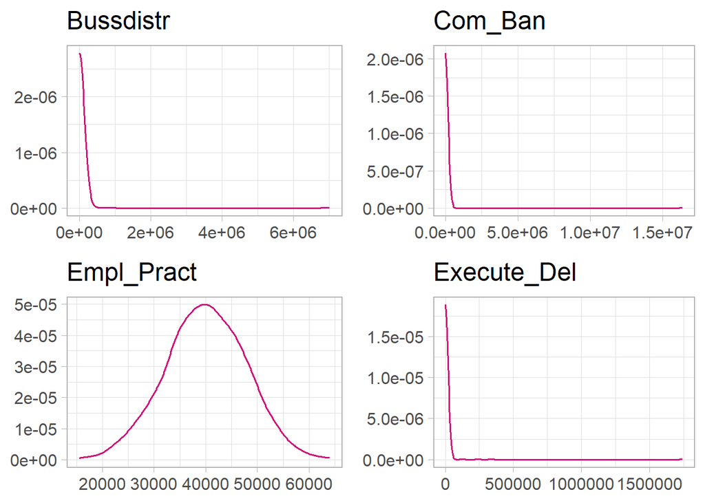

```r
frame_Buss<- data.frame(straty_lista[[1]])
frame_Com<- data.frame(straty_lista[[2]])
frame_Empl<- data.frame(straty_lista[[4]])
frame_Exe<- data.frame(straty_lista[[5]])
p1 <- ggplot()+
  geom_density( data = frame_Buss, aes(x = straty_lista..1..), color = "#CD1076" , size = 0.7) +
  labs (title = "Bussdistr", y = NULL, x = NULL)+
  theme_light(base_size = 15)
p2 <- ggplot()+
  geom_density( data = frame_Com, aes(x = straty_lista..2..), color = "#CD1076" , size = 0.7) +
  labs (title = "Com_Ban", y = NULL, x = NULL)+
  theme_light(base_size = 15)
p3 <- ggplot()+
  geom_density( data = frame_Empl, aes(x = straty_lista..4..), color = "#CD1076", size = 0.7) +
  labs (title = "Empl_Pract", y = NULL, x = NULL)+
  theme_light(base_size = 15)
p4 <- ggplot()+
  geom_density( data = frame_Exe, aes(x = straty_lista..5..),color = "#CD1076" , size = 0.7) +
  labs (title = "Execute_Del", y = NULL, x = NULL)+
  theme_light(base_size = 15)


plot_grid(p1, p2, p3, p4, nrow = 2, ncol = 2)
```

**Buss_distr**

```r
wyniki[c(1:5),]
```

|  | linia | rozklad | parametry | KS_wynik | AD_wynik | AIC |
| --- | --- | --- | --- | --- | --- | --- |
| 1 | Buss_Distr | weibull | shape=0.2849, scale=50.2673 | rejected | rejected | 2473.285 |
| 2 | Buss_Distr | gamma | shape=0.1045, rate=0 | rejected | NA | 2829.695 |
| 3 | Buss_Distr | lnorm | meanlog=2.7611, sdlog=1.7275 | rejected | not computed | 2187.733 |
| 4 | Buss_Distr | exp | rate=0 | rejected | rejected | 5311.081 |
| 5 | Buss_Distr | norm | mean=36008.7655, sd=463690.5213 | rejected | not computed | 6687.251 |

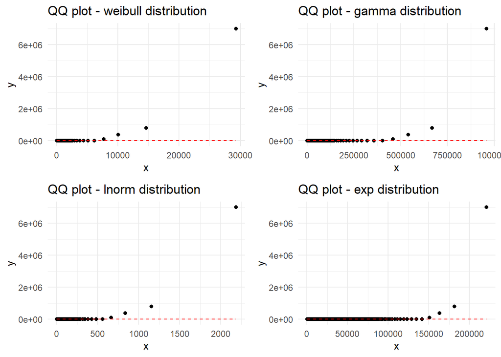

```r
wykres_qq <- function(data, distributions = c("weibull", "gamma", "lnorm", "exp", "norm")) {

  # Ogranicz do 4 pierwszych rozkładów, aby zmieścić się w siatce 2x2
  if (length(distributions) > 4) {
    warning("Pokazuję tylko pierwsze 4 rozkłady, aby zmieścić się w siatce 2x2")
    distributions <- distributions[1:4]
  }

  plots <- list()

  for (i in seq_along(distributions)) {
    dist <- distributions[i]

    tryCatch({
      # Dopasuj rozkład
      fit <- fitdist(data, distr = dist, method = "mle")

      # Stwórz wykres QQ
      plots[[i]] <- ggplot(data.frame(sample = data), aes(sample = sample)) +
        stat_qq(distribution = get(paste0("q", dist)),
                dparams = as.list(fit$estimate)) +
        stat_qq_line(distribution = get(paste0("q", dist)),
                     dparams = as.list(fit$estimate),
                     color = "red", linetype = "dashed") +
        ggtitle(paste("QQ plot -", dist, "distribution")) +
        theme_minimal()

    }, error = function(e) {
      message(sprintf("Błąd dopasowania rozkładu %s: %s", dist, e$message))
      # Pusty wykres w przypadku błędu
      plots[[i]] <- ggplot() +
        annotate("text", x = 0.5, y = 0.5, label = paste("Błąd:", dist)) +
        theme_void()
    })
  }

  # Ustaw siatkę 2x2
  if (length(plots) > 0) {
    grid.arrange(grobs = plots, ncol = 2)
  } else {
    message("Nie udało się utworzyć żadnych wykresów")
  }
}

wykres_qq(frame_Buss$straty_lista..1.., distributions = c("weibull", "gamma", "lnorm", "exp"))
```

Łącząc informacje uzyskane z wykresów, testów oraz AIC, postanowiono dopadować rozkład Buss_dist do rozkładu lnorm. Rozkład BUss_distr jest bardzo specyficzny ze względu na tylko pare wartości ekstremalnie odstającyth oraz reszte wartości dokładnie równych 10.

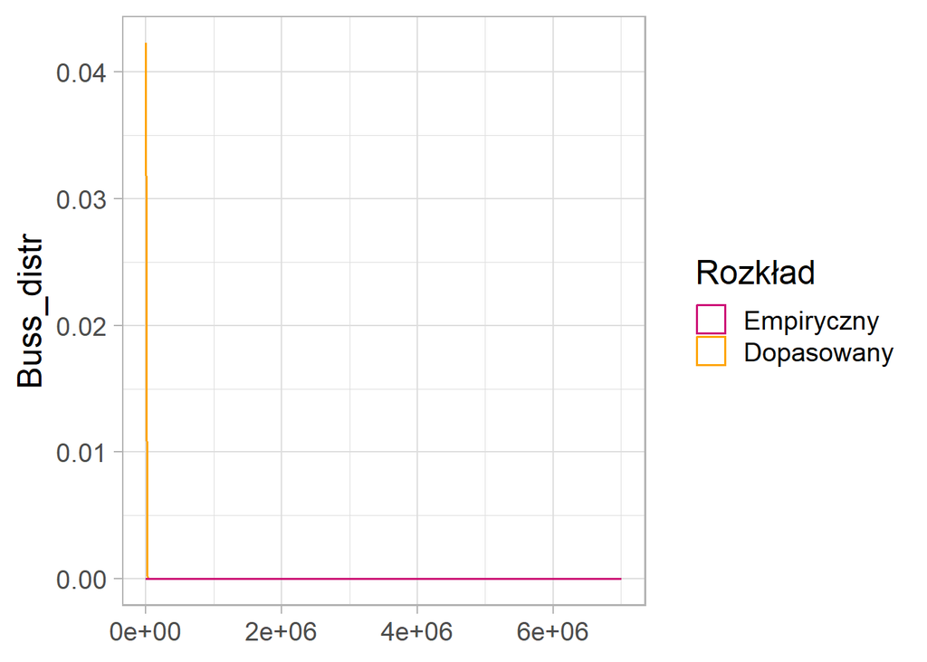

```r
ggplot()+
    geom_density(aes ( x = rlnorm(1000, meanlog = 2.7611, sdlog = 1.72), color = "Dopasowany" ), size = 0.7) +
  geom_density( data = frame_Buss, aes(x = straty_lista..1.., color = "Empiryczny" ), size = 0.7) +

  scale_color_manual(values = c("#CD1076", "orange"), breaks = c("Empiryczny", "Dopasowany"))+
  labs (y = "Buss_distr", x = NULL, colour = "Rozkład")+
  theme_light(base_size = 18)
```

**Com_ban**

```r
wyniki[c(6:10),]
```

|  | linia | rozklad | parametry | KS_wynik | AD_wynik | AIC |
| --- | --- | --- | --- | --- | --- | --- |
| 6 | Com_Ban | weibull | shape=0.3372, scale=20.3404 | rejected | rejected | 4760.295 |
| 7 | Com_Ban | gamma | shape=0.1015, rate=0 | rejected | NA | 5791.898 |
| 8 | Com_Ban | lnorm | meanlog=2.418, sdlog=0.9201 | rejected | not computed | 3750.170 |
| 9 | Com_Ban | exp | rate=0 | rejected | rejected | 11383.742 |
| 10 | Com_Ban | norm | mean=33009.5235, sd=731743.9597 | rejected | not computed | 14896.280 |

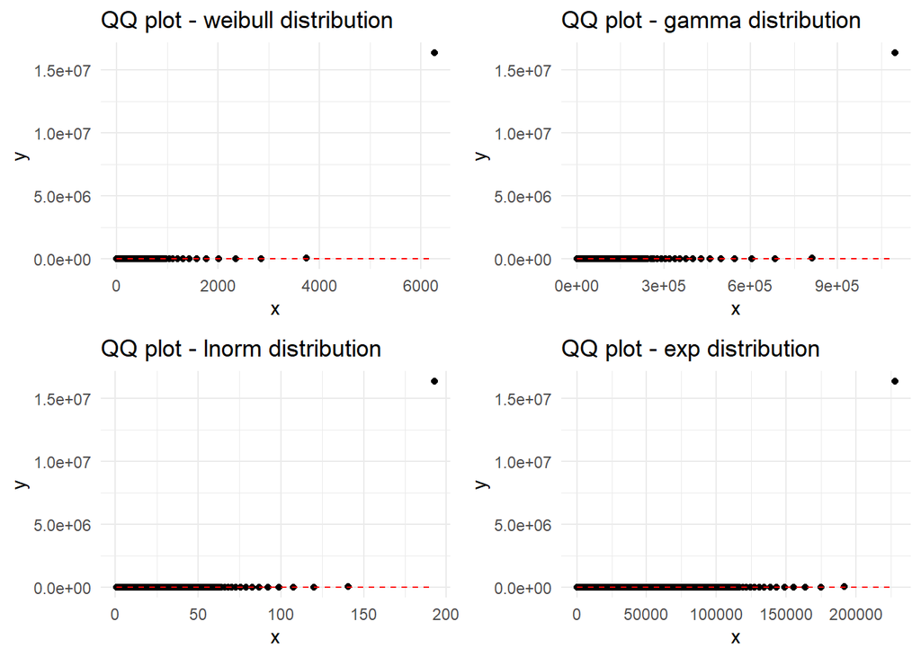

```r
wykres_qq(frame_Com$straty_lista..2.., distributions = c("weibull", "gamma", "lnorm", "exp"))
```

Pomimo tego że z wykresów to rozkład wykładniczy wydaje sie byc najlepszym dopasowaniem, wskażnik AIC daje dokładnie odwrotną informacje. Postanowiono ponownie dopasować rozkład lnorm, do rozkładu wysokości badanych strat.

[figure not shown]

```r
ggplot()+
    geom_density(aes ( x = rlnorm(1000, meanlog = 2.7611, sdlog = 1.72), color = "Dopasowany" ), size = 0.7) +
  geom_density( data = frame_Buss, aes(x = straty_lista..1.., color = "Empiryczny" ), size = 0.7) +

  scale_color_manual(values = c("#CD1076", "orange"), breaks = c("Empiryczny", "Dopasowany"))+
  labs (y = "Buss_distr", x = NULL, colour = "Rozkład")+
  theme_light(base_size = 18)
```

**Expl_pract**

```r
wyniki[c(16:20),]
```

|  | linia | rozklad | parametry | KS_wynik | AD_wynik | AIC |
| --- | --- | --- | --- | --- | --- | --- |
| 16 | Empl_Pract | weibull | shape=5.6914, scale=43177.8782 | rejected | rejected | 45168.17 |
| 17 | Empl_Pract | gamma | shape=24.8572, rate=6e-04 | rejected | rejected | 45203.12 |
| 18 | Empl_Pract | lnorm | meanlog=10.5764, sdlog=0.2059 | rejected | not computed | 45287.89 |
| 19 | Empl_Pract | exp | rate=0 | rejected | rejected | 50424.17 |
| 20 | Empl_Pract | norm | mean=40000, sd=7779.4816 | not rejected | not computed | 45128.34 |

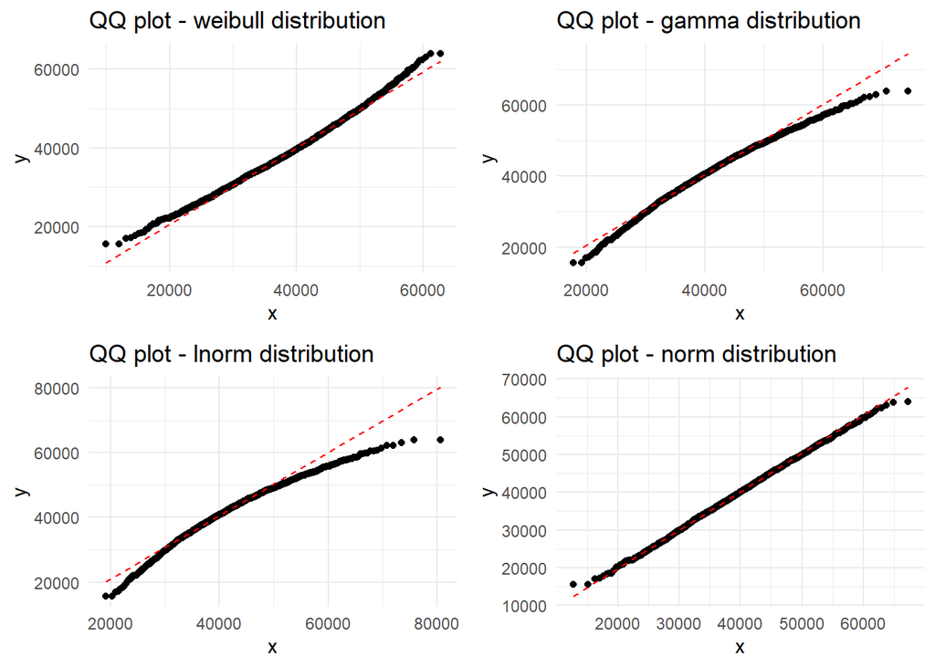

```r
wykres_qq(frame_Empl$straty_lista..4.., distributions = c("weibull", "gamma", "lnorm", "norm"))
```

Zdecydownie, w przypadku rozkałdu Empl_pract, najlepszym dopasowaniem będzie rozkład normalny z wsztskich rozwazanych w badaniu. Tą decyzje popierają wyniki z wszytskich trzech etapów dopasowania: test, AIC oraz wykres QQ.

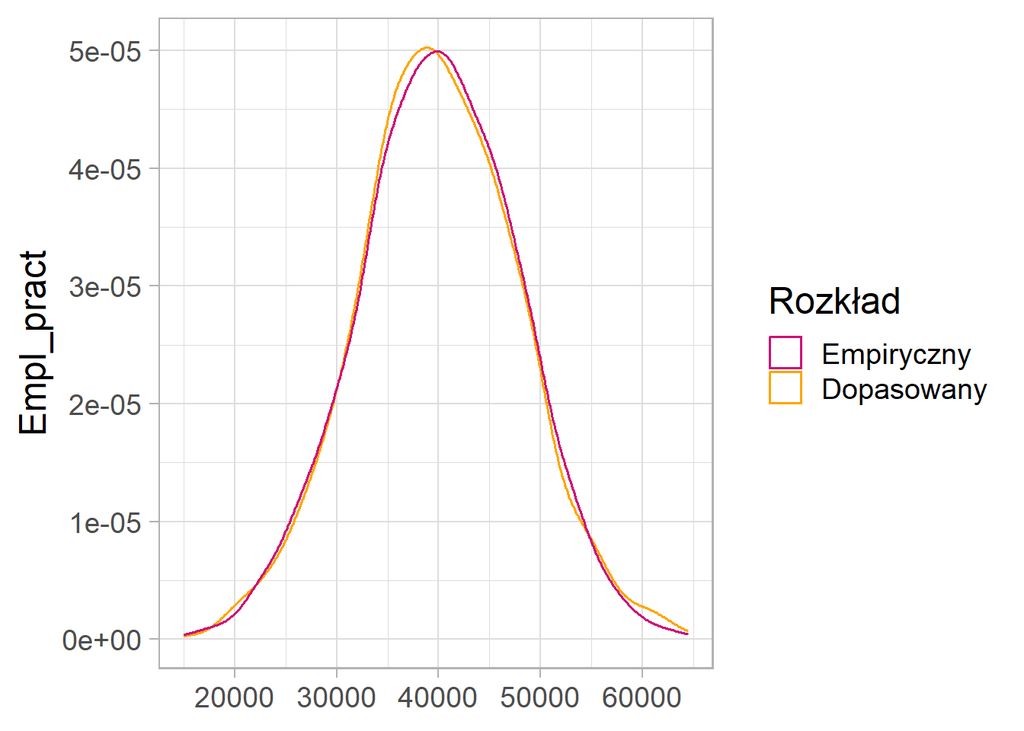

```r
ggplot()+
    geom_density(aes ( x = rnorm(1000, mean = 40000, sd = 7779.48), color = "Dopasowany" ), size = 0.7) +
  geom_density( data = frame_Empl, aes(x = straty_lista..4.., color = "Empiryczny" ), size = 0.7) +

  scale_color_manual(values = c("#CD1076", "orange"), breaks = c("Empiryczny", "Dopasowany"))+
  labs (y = "Empl_pract", x = NULL, colour = "Rozkład")+
  theme_light(base_size = 18)
```

**Execut_Del**

```r
wyniki[c(21:25),]
```

|  | linia | rozklad | parametry | KS_wynik | AD_wynik | AIC |
| --- | --- | --- | --- | --- | --- | --- |
| 21 | Execut_Del | weibull | shape=0.3487, scale=33.0344 | rejected | rejected | 4994.350 |
| 22 | Execut_Del | gamma | shape=0.1323, rate=0 | rejected | NA | 5773.921 |
| 23 | Execut_Del | lnorm | meanlog=2.6047, sdlog=1.319 | rejected | not computed | 4321.721 |
| 24 | Execut_Del | exp | rate=2e-04 | rejected | rejected | 9559.070 |
| 25 | Execut_Del | norm | mean=5009.0132, sd=80020.4179 | rejected | not computed | 12763.812 |

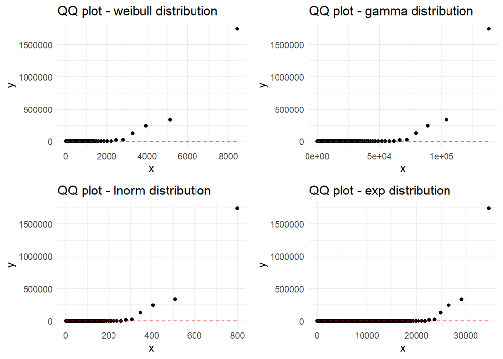

```r
wykres_qq(frame_Exe$straty_lista..5.., distributions = c("weibull", "gamma", "lnorm", "exp"))
```

Ostatnie dopasowanie, pada ponownie na rozkład lnorm, ze względu na wykres oraz kryterium AIC.

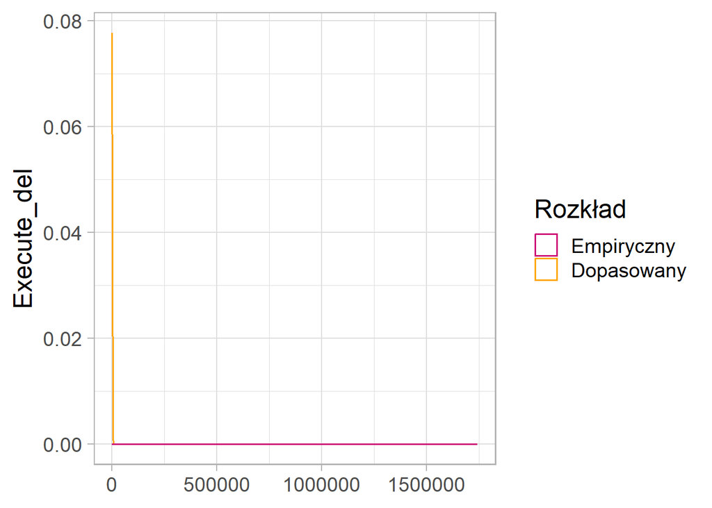

```r
ggplot()+
    geom_density(aes ( x = rlnorm(1000, meanlog = 2.60, sdlog = 1.319), color = "Dopasowany" ), size = 0.7) +
  geom_density( data = frame_Exe, aes(x = straty_lista..5.., color = "Empiryczny" ), size = 0.7) +

  scale_color_manual(values = c("#CD1076", "orange"), breaks = c("Empiryczny", "Dopasowany"))+
  labs (y = "Execute_del", x = NULL, colour = "Rozkład")+
  theme_light(base_size = 18)
```

**Podsumowanie**

W poniższej tabeli zaprezentowano podsumowanie wykonanych dopasowań do rozkładów wartości strat.

```r
colnames(wyniki) <- c("Linia", "Rozkład", "Parametry")
wyniki[c(3,8,14,20,23, 29,34), c(1,2,3)]
```

|  | Linia | Rozkład | Parametry |
| --- | --- | --- | --- |
| 3 | Buss_Distr | lnorm | meanlog=2.7611, sdlog=1.7275 |
| 8 | Com_Ban | lnorm | meanlog=2.418, sdlog=0.9201 |
| 14 | Damage | exp | rate=2e-04 |
| 20 | Empl_Pract | norm | mean=40000, sd=7779.4816 |
| 23 | Execut_Del | lnorm | meanlog=2.6047, sdlog=1.319 |
| 29 | External_Fr | exp | rate=2e-04 |
| 34 | Internal_Fr | exp | rate=2e-04 |

```r
pod
```

[output not shown]

# Symulacja

Teoretyczne rozkłady wysokości i częstości występowania start są niezbęde do przeprowadzenia symulacji wartości strat. Dzięki wygenerowaniu wysokiej liczby scenariuszy, mozliwym jest zamodelowanie Wartości starty jakiej na 99.9% nie przekroczymy. Ustalenie tej wartości nastepuje poprzez obliczenie konkretmego kwantyla z rozkładu scenariuszy. W badaniu wygenerowano 20 000 scenariuszy, gdzie każdy scenariusz to suma z wszytskich strat uzyskanych z jendego losowania w ramach każdej linii.

Poniżej przykładowe scenariusze z wszytskich wygenerowanych:

```r
symulacja <- function(){
   result <- data.frame(Buss_distr = rep(0,20000), Com_Ban = rep(0,20000), Damage = rep(0,20000), Empl_Pract = rep(0,20000), Execute_Del = rep(0,20000), External_Fr =rep(0,20000), Internal_FR =rep(0,20000))

   for (i in c(1:20000)) {
     result$Buss_distr[i] = sum(rlnorm(n = rbinom(1,size = dwu_df1$n[1], prob= dwu_df1$p[1]), meanlog =2.76, sdlog = 1.72))

     result$Com_Ban[i] = sum(rlnorm(n = rbinom(1,size = dwu_df1$n[2], prob= dwu_df1$p[2]), meanlog =2.4, sdlog = 0.9))

     result$Damage[i] = sum(rexp(n = rnbinom(n = 1, size = dwu_uj$size[1], mu = dwu_uj$mu[1]), rate = 0.0002))

     result$Empl_Pract[i] = sum(rnorm(n = rpois(1,lambda = 62), mean =2.76, sd = 1.72))

     result$Execute_Del[i] = sum(rlnorm(n = rbinom(1,size = dwu_df1$n[3], prob= dwu_df1$p[3]), meanlog =2.76, sdlog = 1.72))

     result$External_Fr[i] = sum(rexp(n = rbinom(1,size = dwu_df1$n[4], prob= dwu_df1$p[4]), rate = 0.0002))

     result$Internal_FR[i] = sum(rlnorm(n = rnbinom(n = 1, size = dwu_uj$size[2], mu = dwu_uj$mu[2]), meanlog =2.60, sdlog = 1.31))
   }


result$Strata = apply(result, 1, sum)
return(result)
}

wyniki <- symulacja()

head(wyniki)
```

|  | Buss_distr | Com_Ban | Damage | Empl_Pract | Execute_Del | External_Fr | Internal_FR | Strata |
| --- | --- | --- | --- | --- | --- | --- | --- | --- |
| 1 | 0.00000 | 17.866963 | 22758.50 | 175.2400 | 1225.3969 | 0.000 | 2294.136 | 26471.14 |
| 2 | 0.00000 | 37.343886 | 120400.40 | 236.9233 | 1387.1337 | 0.000 | 2259.412 | 124321.22 |
| 3 | 0.00000 | 108.572982 | 123018.77 | 135.9824 | 2066.6320 | 17788.442 | 3578.047 | 146696.45 |
| 4 | 0.00000 | 4.233285 | 225637.67 | 215.8637 | 1027.1883 | 9352.356 | 2545.347 | 238782.66 |
| 5 | 67.09777 | 9.469846 | 259693.84 | 130.0909 | 636.9118 | 2243.608 | 3385.841 | 266166.86 |
| 6 | 0.00000 | 7.514681 | 27298.14 | 161.6050 | 1276.0986 | 0.000 | 2544.987 | 31288.35 |

Same pokazanie scenariuszy to mało, ponizej zaprezentowano statystyki opisowe dla każdej ze zmiennych oraz dla ich sumy

```r
statystyki_opisowe <- describe(wyniki)
statystyki_opisowe[,c(3,4,5,8,9)]
```

|  | mean | sd | median | min | max |
| --- | --- | --- | --- | --- | --- |
| Buss_distr | 17.88867 | 122.38752 | 0.00000 | 0.00000 | 9585.6702 |
| Com_Ban | 23.36242 | 28.91194 | 14.35088 | 0.00000 | 417.6552 |
| Damage | 92011.21818 | 54765.76722 | 82975.32984 | 0.00000 | 556946.2294 |
| Empl_Pract | 171.22679 | 25.61969 | 170.44221 | 85.55909 | 289.7171 |
| Execute_Del | 1967.03632 | 1680.99987 | 1601.00932 | 174.16921 | 70592.7310 |
| External_Fr | 6260.03654 | 7828.88530 | 3513.61516 | 0.00000 | 73024.9497 |
| Internal_FR | 3193.30870 | 856.46910 | 3095.27369 | 917.32803 | 13943.6476 |
| Strata | 103644.07762 | 55417.64020 | 94784.43317 | 3712.28229 | 571194.9242 |

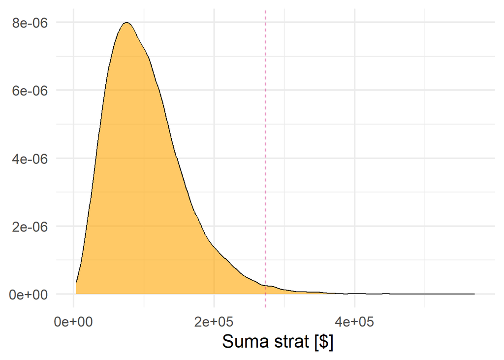

```r
wyniki %>%
  ggplot() +
  geom_density(aes(x = wyniki$Strata), fill = "orange", alpha = 0.6) +
  geom_vline(xintercept = quantile(wyniki$Strata, 0.99), linetype = "dashed", color = "#CD1076")+
  theme_minimal(base_size = 18) +
  labs(
    title = NULL,
    x = " Suma strat [$]",
    y = NULL
  )
```

Powyżej przedstawiono wyniki jednej przykładowej symulacji. Taką procedure losowania 20000 scenariuszy i wyznaczania OpVar i OpES powtórzono 100 razy oraz wyciagnięto średnią z wyników aby ustalic przwdziwą wysokość rozważanych indeksów ryzyka.

**Wyniki**

Interpretacja wyników jest następująca: Na 99.9% strata nie przkroczy wartości OpVar, natomiast jeżeli przekroczy to przecietnie wyniesie wartość OpES. Poniżej zaprezentowano parę przykładowych wyników.

```r
res <- data.frame(Var = rep(0,100), ES = rep(0,100))
```

```r
for(i in c(1:100)) {
  wynik <- symulacja()
  res$Var[i] <- quantile(wynik$Strata, 0.999)
  res$ES[i] <- mean(wynik$Strata[wynik$Strata > res$Var[i]])
}
head(res)
```

|  | Var | ES |
| --- | --- | --- |
| 1 | 352884.7 | 378759.9 |
| 2 | 348905.0 | 391896.8 |
| 3 | 355939.1 | 383853.4 |
| 4 | 367715.8 | 388140.9 |
| 5 | 354759.0 | 386086.9 |
| 6 | 375835.2 | 411261.3 |

Dla rozważanych w badaniu danych OpVar oraz ES wyniosły:

```r
u <- data.frame(mean(res$Var), mean(res$ES))
colnames(u) <- c("VaR", "ES")
u
```

| VaR | ES |
| --- | --- |
| 358750.6 | 394291.4 |

# Podsumowanie

W badaniu przeprowadzono próbe wyestymowanie operacyjnego Var’u oraz ES, dzieki modelowi AMA. Moje dopasowania okazały się w miare trafne, ponieważ szanowany badacz Jakub Wasiczek, laureat konferencji barbórkowej w sekcji Ekonomia Ekonometria i Anliza Danych, osiagnał podobne wyniki, co bardzo mnie cieszy. Sam model AMA i całą jego procedure oceniam na w miarę przyjemną, ciekawi mnie jak w branży dopasowywują te rozkłady i czy to się serio udaje.